# PS6-Shengwenxin-Ni

```r
library(patchwork)
library(rcfss)
library(e1071)
library(caret)
```

# Question 1

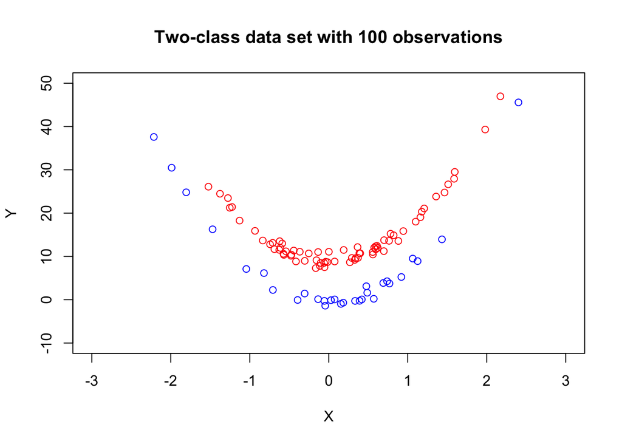

```r
library(e1071)
set.seed(1)
x = rnorm(100)
y = 8 * x^2 +4 + rnorm(100)
class = sample(100, 70)
y[class] = y[class] + 5
y[-class] = y[-class] - 5
plot(x[class], y[class], col = "red",
     xlab = "X", ylab = "Y",
     ylim = c(-10, 50),xlim = c(-3, 3 ),
     main = 'Two-class data set with 100 observations' )
points(x[-class], y[-class], col = "blue")
```

## Case 1: Kernel = Linear

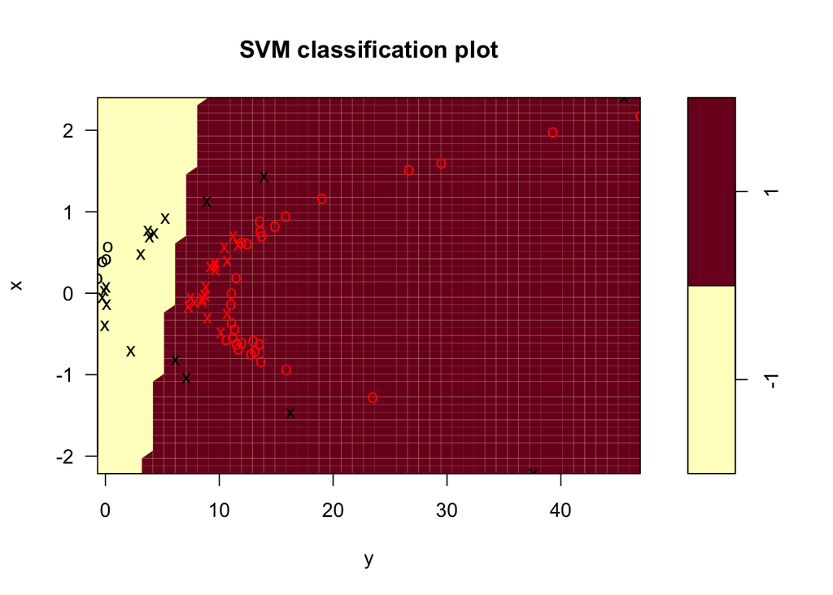

```r
z = rep(-1, 100)
z[class] = 1
data = data.frame(x = x, y = y, z = as.factor(z))
train = sample(100, 70)
data.train = data[train, ]
data.test = data[-train, ]
svm.linear = svm(z ~ ., data = data.train, kernel = "linear", cost = 10)
plot(svm.linear, data.train)
```

## Case 2: Kernel = Polynomial

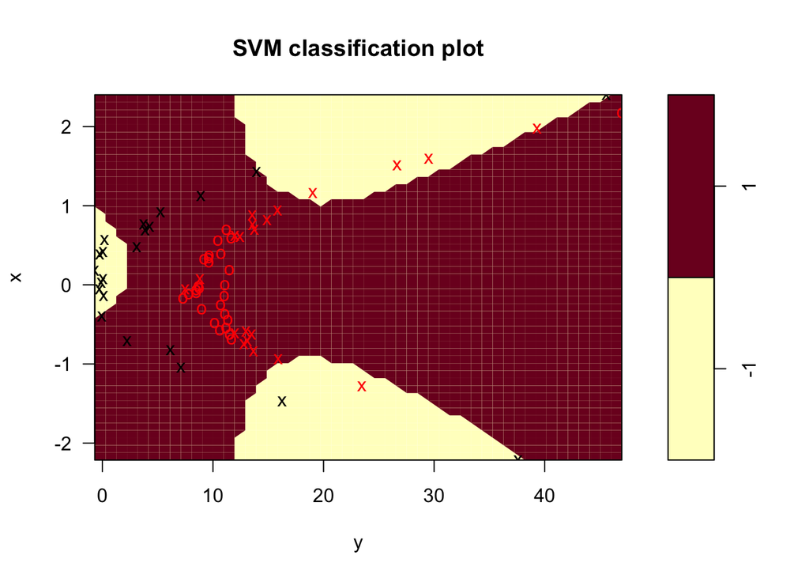

```r
svm.poly = svm(z ~ ., data = data.train, kernel = "polynomial", cost = 10)
plot(svm.poly, data.train)
```

## Case 3: Kernel = Radial

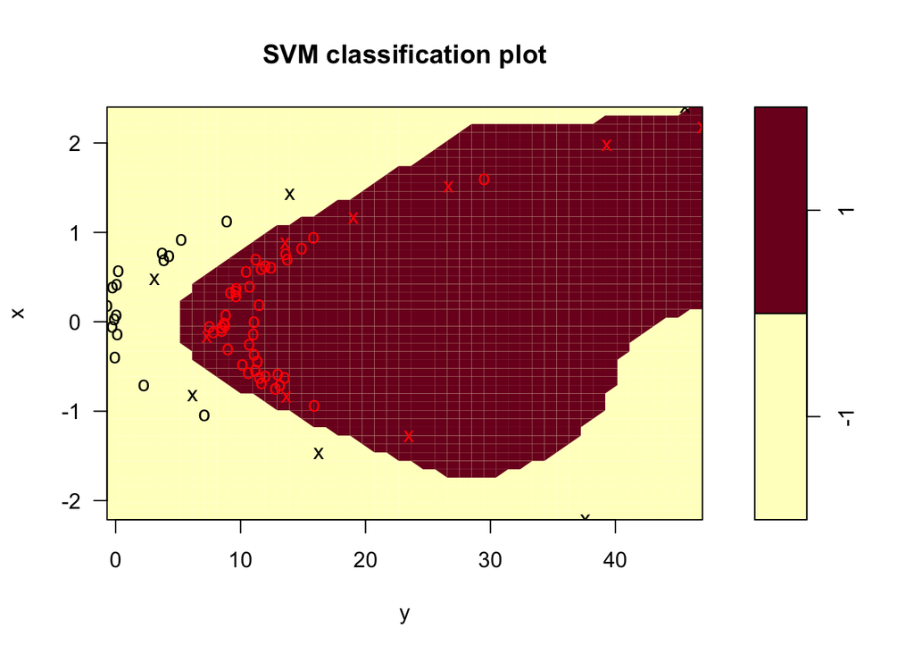

```r
svm.radial = svm(z ~ ., data = data.train, kernel = "radial", cost = 10)
plot(svm.radial, data.train)
```

## Errors on the training set

```r
table(predict = predict(svm.linear, data.train), truth = data.train$z)
```

```
##        truth
## predict -1  1
##      -1 15  0
##      1   7 48
```

```r
table(predict = predict(svm.poly, data.train), truth = data.train$z)
```

```
##        truth
## predict -1  1
##      -1 10  4
##      1  12 44
```

```r
table(predict = predict(svm.radial, data.train), truth = data.train$z)
```

```
##        truth
## predict -1  1
##      -1 21  0
##      1   1 48
```

## Fit on the testing data

```r
table(predict = predict(svm.linear, data.test), truth = data.test$z)
```

```
##        truth
## predict -1  1
##      -1  5  0
##      1   3 22
```

```r
table(predict = predict(svm.poly, data.test), truth = data.test$z)
```

```
##        truth
## predict -1  1
##      -1  5 10
##      1   3 12
```

```r
table(predict = predict(svm.radial, data.test), truth = data.test$z)
```

```
##        truth
## predict -1  1
##      -1  8  0
##      1   0 22
```

All the statistics above show that SVM classifier with a RADIAL kernel is the best technique, not only on the training data set but on the testing data set as well.

# Question 2: Generate a data set

```r
set.seed(828)
x1 <- runif(500) - 0.5
x2 <- runif(500) - 0.5
y <- as.integer(x1 ^ 2 - x2 ^ 2 > 0)
```

# Question 3: Plot the observations

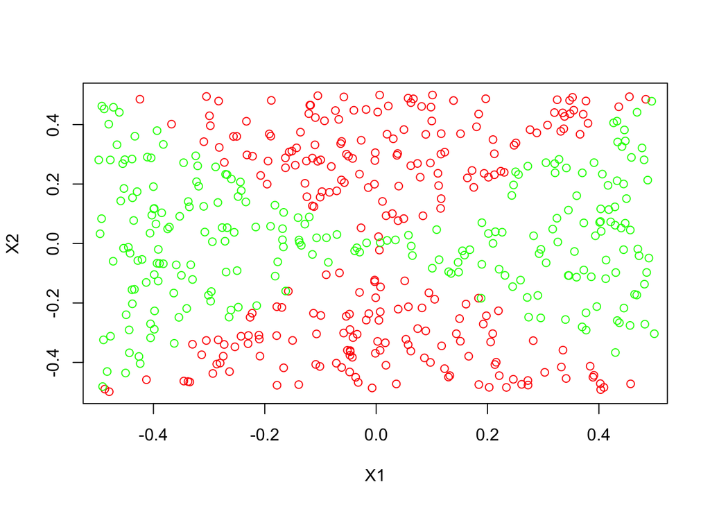

```r
plot(x1[y == 0], x2[y == 0],col = "red", xlab = "X1", ylab = "X2")
points(x1[y == 1], x2[y == 1], col = 'green')
```

# Question 4: Fit a logistic regression

```r
dat <- data.frame(x1 = x1, x2 = x2, y = as.factor(y))
lr.fit <- glm(y ~ ., data = dat, family = 'binomial')
summary(lr.fit)
```

```
##
## Call:
## glm(formula = y ~ ., family = "binomial", data = dat)
##
## Deviance Residuals:
##    Min      1Q  Median      3Q     Max
## -1.245  -1.139  -1.063   1.189   1.331
##
## Coefficients:
##             Estimate Std. Error z value Pr(>|z|)
## (Intercept) -0.09173    0.08989  -1.021    0.307
## x1          -0.45431    0.31597  -1.438    0.150
## x2           0.11611    0.31038   0.374    0.708
##
## (Dispersion parameter for binomial family taken to be 1)
##
##     Null deviance: 692.18  on 499  degrees of freedom
## Residual deviance: 690.01  on 497  degrees of freedom
## AIC: 696.01
##
## Number of Fisher Scoring iterations: 3
```

# Question 5: Obtain a predicted class label

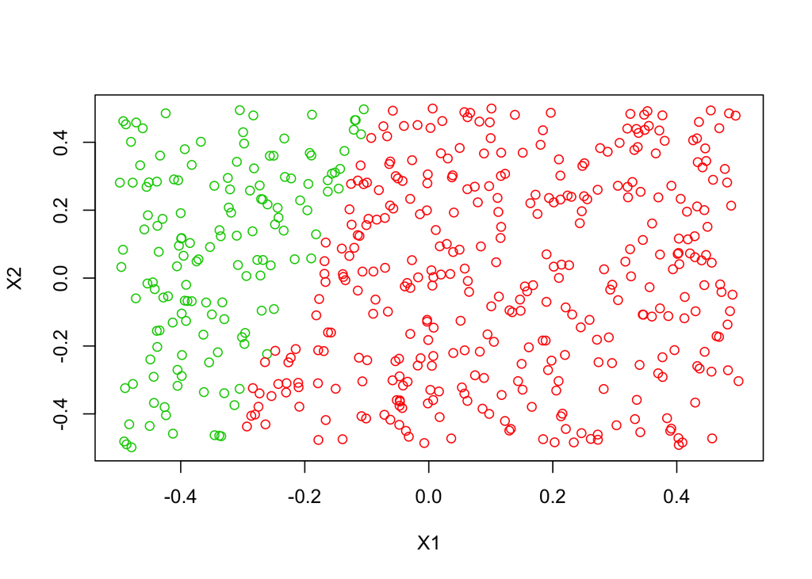

```r
lr.prob <- predict(lr.fit, newdata = dat, type = 'response')
lr.pred <- ifelse(lr.prob > 0.5, 1, 0)
plot(dat$x1, dat$x2, col = lr.pred + 2,xlab = "X1", ylab = "X2")
```

The predicted decision boundary looks linear because it’s almost a straight line.

# Question 6: Fit a logistic regression with a non-linear function

```r
lr.nl <- glm(y ~ poly(x1, 2) + poly(x2, 2), data = dat, family = 'binomial')
summary(lr.nl)
```

```
##
## Call:
## glm(formula = y ~ poly(x1, 2) + poly(x2, 2), family = "binomial",
##     data = dat)
##
## Deviance Residuals:
##        Min          1Q      Median          3Q         Max
## -2.318e-03  -2.000e-08  -2.000e-08   2.000e-08   3.081e-03
##
## Coefficients:
##               Estimate Std. Error z value Pr(>|z|)
## (Intercept)     -228.2    15009.7  -0.015    0.988
## poly(x1, 2)1     193.5   121990.7   0.002    0.999
## poly(x1, 2)2   79013.6  1186940.1   0.067    0.947
## poly(x2, 2)1   -2736.7    96535.5  -0.028    0.977
## poly(x2, 2)2  -81000.0  1256738.8  -0.064    0.949
##
## (Dispersion parameter for binomial family taken to be 1)
##
##     Null deviance: 6.9218e+02  on 499  degrees of freedom
## Residual deviance: 2.0338e-05  on 495  degrees of freedom
## AIC: 10
##
## Number of Fisher Scoring iterations: 25
```

# Question 7: Obtain a predicted class label

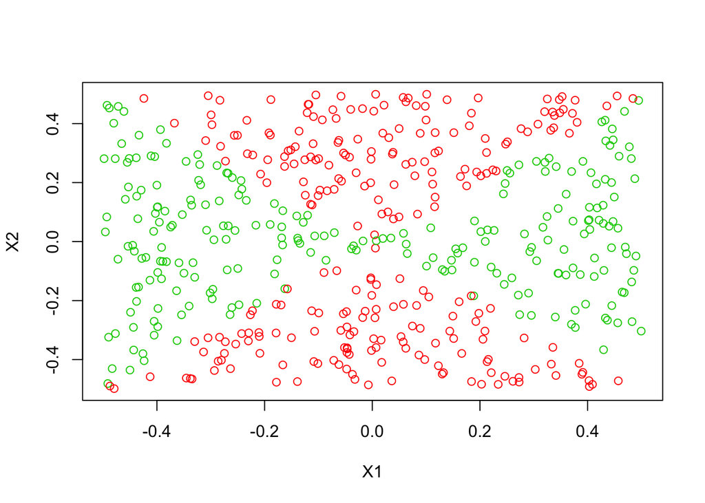

```r
lr.prob.nl <- predict(lr.nl, newdata = dat, type = 'response')
lr.pred.nl <- ifelse(lr.prob.nl > 0.5, 1, 0)
plot(dat$x1, dat$x2, col = lr.pred.nl + 2,xlab = "X1", ylab = "X2")
```

The decision boundary is obviously non-linear because it’s not a simple straight line.

# Question 8: Fit a support vector classifier (linear kernel)

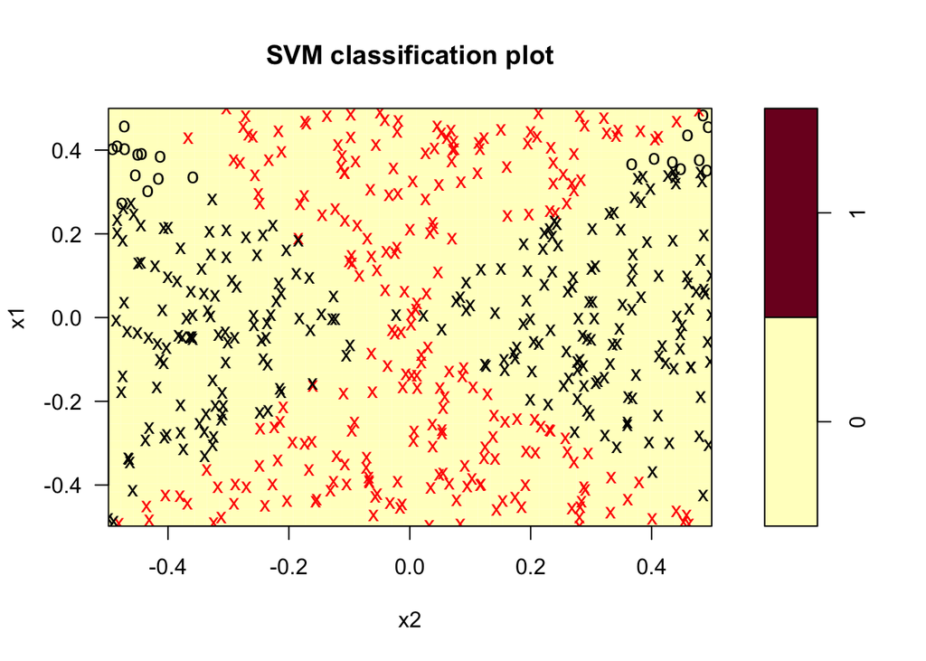

```r
svm.lin <- svm(y ~ ., data = dat, kernel = 'linear', cost = 0.01)
plot(svm.lin, dat)
```

# Question 9: Fit a SVM using a non-linear kernel to the data.

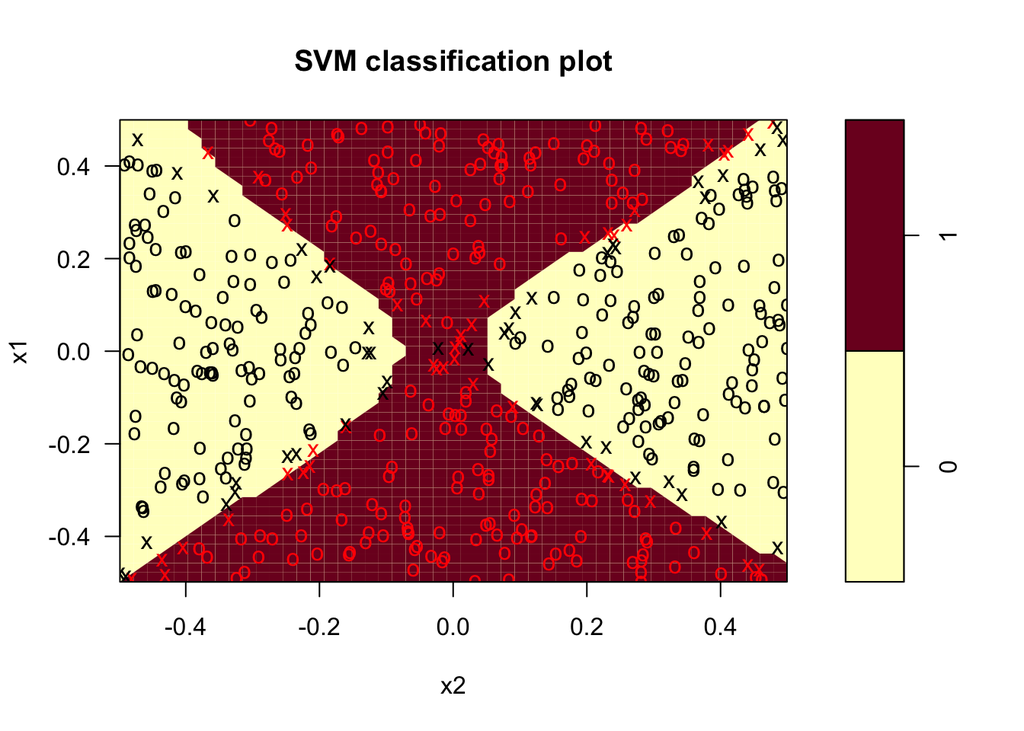

```r
svm.nl <- svm(y ~ ., data = dat, kernel = 'radial', gamma = 1,cost = 5)
plot(svm.nl, data = dat)
```

# Question 10 : Comments To estimating non-linear decision boundaries, SVM with the linear kernel and logistic regression without any interaction term are not effective enough.Fortunately, both SVM with a non-linear kernel (in this case, radial) and logistic regression with a non-linear function (in this case, polynomial of degree two) are powerful in classfication. However, it takes time for us for finding an proper non-linear function for the logistic regression and tuning gamma and cost for SVM.

## Question 11 :

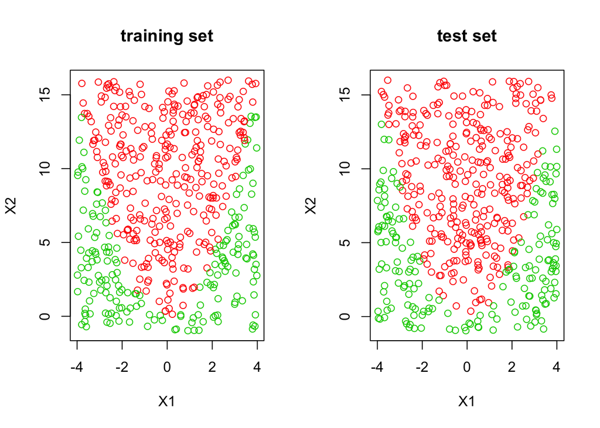

```r
set.seed(317)
obs = 1000
x1 <- runif(obs, min = -4, max = 4)
x2 <- runif(obs, min = -1, max = 16)
y <- ifelse(x2 > x1 ^ 2, 0, 1)
dat <- data.frame(x1 = x1, x2 = x2, y = as.factor(y))
train <- sample(obs, obs/2)
dat.train <- dat[train, ]
dat.test <- dat[-train, ]
par(mfrow = c(1,2))
plot(dat.train$x1, dat.train$x2, col = as.integer(dat.train$y) + 1,
     xlab = "X1", ylab = "X2",main = 'training set')
plot(dat.test$x1, dat.test$x2, col = as.integer(dat.test$y) + 1,
     xlab = "X1", ylab = "X2",main = 'test set')
```

## Question 12.1 CV error rates

```r
set.seed(828)
cost.grid <- c(0.001, 0.01, 0.1, 1, 5, 10, 100, 10000)
tune.out <- tune(svm, y ~., data = dat.train, kernel = 'linear', ranges = list(cost = cost.grid))
summary(tune.out)
```

```
##
## Parameter tuning of 'svm':
##
## - sampling method: 10-fold cross validation
##
## - best parameters:
##  cost
##   0.1
##
## - best performance: 0.21
##
## - Detailed performance results:
##    cost error dispersion
## 1 1e-03 0.362 0.06629899
## 2 1e-02 0.214 0.06603030
## 3 1e-01 0.210 0.06200358
## 4 1e+00 0.212 0.06679987
## 5 5e+00 0.210 0.06411795
## 6 1e+01 0.210 0.06411795
## 7 1e+02 0.212 0.06679987
## 8 1e+04 0.248 0.10799177
```

From the summary table,it’s clear that as cost value increases, cv error rate decreases and then increases. The best error rate 0.210 (105 errors out of 500) is achieved when cost = 0.1.

## Question 12.2 Training error rates

```r
set.seed(828)
err.rate.train <- rep(NA, length(cost.grid))
for (cost in cost.grid) {
  svm.fit <- svm(y ~ ., data = dat.train, kernel = 'linear', cost = cost)
  res <- table(prediction = predict(svm.fit, newdata = dat.train), truth = dat.train$y)
  err.rate.train[match(cost, cost.grid)] <- (res[2,1] + res[1,2]) / sum(res)
}


for (err in err.rate.train){cat( 'number of errors (out of 500):',err*500,'; error rate:',err, '\n')}
```

```
## number of errors (out of 500): 181 ; error rate: 0.362
## number of errors (out of 500): 107 ; error rate: 0.214
## number of errors (out of 500): 104 ; error rate: 0.208
## number of errors (out of 500): 107 ; error rate: 0.214
## number of errors (out of 500): 107 ; error rate: 0.214
## number of errors (out of 500): 107 ; error rate: 0.214
## number of errors (out of 500): 107 ; error rate: 0.214
## number of errors (out of 500): 181 ; error rate: 0.362
```

From the results above, we can see that the error rates for the training data has a SIMILAR pattrern compared to that of CV: as the cost value increases, the error rate decreases and then increases. Therefore, the best error rate 0.208 (104 errors) is achieved at a middle value where cost = 0.1.

# Question 13 Test Errors

```r
set.seed(828)
err.rate.test <- rep(NA, length(cost.grid))
for (cost in cost.grid) {
  svm.fit <- svm(y ~ ., data = dat.train, kernel = 'linear', cost = cost)
  res <- table(prediction = predict(svm.fit, newdata = dat.test), truth = dat.test$y)
  err.rate.test[match(cost, cost.grid)] <- (res[2,1] + res[1,2]) / sum(res)
}

for (err in err.rate.test){cat( 'number of errors (out of 500):',err*500,'; error rate:',err, '\n')}
```

```
## number of errors (out of 500): 187 ; error rate: 0.374
## number of errors (out of 500): 119 ; error rate: 0.238
## number of errors (out of 500): 121 ; error rate: 0.242
## number of errors (out of 500): 124 ; error rate: 0.248
## number of errors (out of 500): 124 ; error rate: 0.248
## number of errors (out of 500): 124 ; error rate: 0.248
## number of errors (out of 500): 124 ; error rate: 0.248
## number of errors (out of 500): 187 ; error rate: 0.374
```

The best error rate 0.238 (119 errors out of 500) is generated when cost = 0.01, which is different from what we’ve got in the training and cv. However, when cost = 0.1, we get the second best error rate 0.242 (121 errors out of 500), which is every close to 0.238. In addition, the pattern of error rates of the testing dataset is very similar to that of the training and CV.

# Question 14: Comments

Generally, it’s true that the a support vector classifier with a small value of cost (best cost value at either 0.01 or 0.1) would perform better than the one with a huge value of cost because the large costs tend to overfit the data with a narrow margin. However, according to the output error rate, an extremly cost value can be problematic as well. Perhaps, this is because when a cost value become too small, the margin becomes too wide and therefore the classifier loses its function to classify.

# Question 15: Fit a SVC to predict colrac

```r
library(tidyverse)
train <- read_csv("/Users/nishengwenxin/Documents/GitHub/problem-set-6/data/gss_train.csv")
test <- read_csv("/Users/nishengwenxin/Documents/GitHub/problem-set-6/data/gss_test.csv")
set.seed(317)
tune.lin <- tune(svm,  colrac ~ ., data = train, kernel = 'linear',  ranges = list(cost = c(0.01, 0.1, 1, 10, 100)))
summary(tune.lin)
```

```
##
## Parameter tuning of 'svm':
##
## - sampling method: 10-fold cross validation
##
## - best parameters:
##  cost
##  0.01
##
## - best performance: 0.1824688
##
## - Detailed performance results:
##    cost     error dispersion
## 1 1e-02 0.1824688 0.03455097
## 2 1e-01 0.2001474 0.03693214
## 3 1e+00 0.2018619 0.03707543
## 4 1e+01 0.2020248 0.03711540
## 5 1e+02 0.2036360 0.03771240
```

The cost and its cv errors are shown above. We can see that the lowest error rate, 0.1825 , is achieved when cost = 0.01

Here’s the prediction based on this model on the test dataset.

```r
svm.lin <- svm(colrac ~., data=train, kernel='linear', cost=0.01)
table(predict=ifelse(predict(svm.lin, test) > 0.5, 1, 0),
      truth=test$colrac)
```

```
##        truth
## predict   0   1
##       0 117  27
##       1 111 238
```

Therefore, the error rate is (27+111)/493 = 0.2799189

# Question 16.1 Polynomial

```r
set.seed(317)
tune.pol <- tune(svm, colrac ~ ., data = train, kernel = "polynomial", ranges = list(cost =  c(0.01, 0.1, 1, 10,100), degree = c(2, 3, 4)))
summary(tune.pol)
```

```
##
## Parameter tuning of 'svm':
##
## - sampling method: 10-fold cross validation
##
## - best parameters:
##  cost degree
##     1      3
##
## - best performance: 0.1508771
##
## - Detailed performance results:
##     cost degree     error dispersion
## 1  1e-02      2 0.4069594 0.05238911
## 2  1e-01      2 0.2650561 0.04257608
## 3  1e+00      2 0.2144517 0.02881145
## 4  1e+01      2 0.3388261 0.03612677
## 5  1e+02      2 0.7321140 0.05703195
## 6  1e-02      3 0.3707318 0.05440989
## 7  1e-01      3 0.1818832 0.01876158
## 8  1e+00      3 0.1508771 0.01836615
## 9  1e+01      3 0.1644648 0.01880756
## 10 1e+02      3 0.1677873 0.01885370
## 11 1e-02      4 0.4157084 0.05293953
## 12 1e-01      4 0.3120294 0.05016980
## 13 1e+00      4 0.1874862 0.01438474
## 14 1e+01      4 0.1886626 0.01514388
## 15 1e+02      4 0.1891127 0.01518010
```

Each combination of cost and degrees and its cv error is shown above. We can see that the lowest error rate, 0.1508771 , is achieved when cost = 1 and degree = 3.

Here’s the prediction based on this model on the test dataset.

```r
svm.poly <- svm(colrac ~., data=train, kernel='polynomial', cost=1, degree = 3)
table(predict=ifelse(predict(svm.poly, test) > 0.5, 1, 0),
      truth=test$colrac)
```

```
##        truth
## predict   0   1
##       0 153  45
##       1  75 220
```

# Question 16.2 Radial

```r
set.seed(317)
tune.rad <- tune(svm, colrac ~ ., data = train, kernel = "radial", ranges = list(cost =  c(0.01, 0.1, 1, 10,100), gamma = c(0.01,0.1, 1, 10,100)))
summary(tune.rad)
```

```
##
## Parameter tuning of 'svm':
##
## - sampling method: 10-fold cross validation
##
## - best parameters:
##  cost gamma
##     1  0.01
##
## - best performance: 0.1482373
##
## - Detailed performance results:
##     cost gamma     error  dispersion
## 1  1e-02 1e-02 0.2816476 0.046815324
## 2  1e-01 1e-02 0.1557981 0.020284801
## 3  1e+00 1e-02 0.1482373 0.025491717
## 4  1e+01 1e-02 0.1653820 0.023284216
## 5  1e+02 1e-02 0.1786241 0.023917267
## 6  1e-02 1e-01 0.4245661 0.052174015
## 7  1e-01 1e-01 0.3809059 0.047745324
## 8  1e+00 1e-01 0.2169045 0.007585243
## 9  1e+01 1e-01 0.2176226 0.007373063
## 10 1e+02 1e-01 0.2176226 0.007373063
## 11 1e-02 1e+00 0.4258930 0.052257159
## 12 1e-01 1e+00 0.3935146 0.048399347
## 13 1e+00 1e+00 0.2500083 0.003193815
## 14 1e+01 1e+00 0.2500083 0.003193815
## 15 1e+02 1e+00 0.2500083 0.003193815
## 16 1e-02 1e+01 0.4258931 0.052257157
## 17 1e-01 1e+01 0.3935149 0.048399351
## 18 1e+00 1e+01 0.2500101 0.003195659
## 19 1e+01 1e+01 0.2500101 0.003195659
## 20 1e+02 1e+01 0.2500101 0.003195659
## 21 1e-02 1e+02 0.4258931 0.052257157
## 22 1e-01 1e+02 0.3935149 0.048399351
## 23 1e+00 1e+02 0.2500101 0.003195659
## 24 1e+01 1e+02 0.2500101 0.003195659
## 25 1e+02 1e+02 0.2500101 0.003195659
```

Each combination of cost and gamma and its cv error is shown above. We can see that the lowest error rate, 0.1482373, is achieved when cost = 1 and gamma = 0.01.

Here’s the prediction based on this model on the test dataset.

```r
svm.rad <- svm(colrac ~., data=train, kernel='radial', cost=1, gamma = 0.01)
table(predict=ifelse(predict(svm.rad, test) > 0.5, 1, 0),
      truth=test$colrac)
```

```
##        truth
## predict   0   1
##       0 154  34
##       1  74 231
```

# 16.3 Comments

The smallest CV error rate for a tuned SVM classifer are: Linear: 0.1825 Polynomial: 0.1508771 Radial: 0.1482373

In terms of the error rate, we can see that a SVM classifier with its best tuned parameter perform better with a non-linear kernel. And for above two SVM classifiers with non-linear kernels, the best models both take cost = 1. However, cost for the linear model takes 0.01 that suggests a wide range of margin and the insigificant difference between the resulting cv error rates (0.18 to 0.20) suggests that the model is performing badly on the dataset. Fortunately, SVM classifiers with kernel = polynomial and radial performs well. The radial one is even slightly better in both CV errors and the testing errors. Perhaps, we do should use radial SVM to interprete colrac by other features.